# Chapter 2: Getting Started

# Chapter 2: Getting Started

In Chapter 2 of *Price Analysis* we covered many sources for obtaining price and market fundamental data. In this chapter of the R companion, we will learn how to import these data in a variety of ways, including an API (application program interface) call. Using API’s greatly reduce the work and time required to get up and running with an analysis, and more entities provide API access all the time.

We will keep the introduction here to the bare minimum required to get us up and running and performing price analysis.

## Data Import From Files on Your Hard Drive

Beginning analysis with R usually involves importing data from our hard drive. First we will download some data from Quandl.

Navigate to where CZ2015 (December 2015 Corn future) is housed.

[figure not shown]

There is a button that says ‘download’ above the chart of the prices. When you click it, you will see file format options. We will work with CSV the most, but will learn how to import Excel files as well. We will not use json or XML file formats in this book.

### From Comma Separated Files

Let’s begin by loading the price data into R in the CSV format. Click the ‘Download’ button and then right-click ‘CSV’. Choose ‘Save Link As’. This gives you the ability to save it directly into your Chapter1 R project folder. If you click ‘CSV’ instead of right-click, the CSV file will automatically download into your ‘Downloads’ folder. This is OK, but you will need to go through the extra step of copy and pasting the CSV file into your Chapter1 project folder.

Now we have the data on our hard drive, and we will load it into R for analysis! The `read.csv()` function looks for the file `CME-CZ2015.csv` in the working directory (file on your hard drive) and loads it into the R environment as a data.frame. In the “Environment” tab of the upper right pane of the RStudio console you should see the variable `CZ2015`. If you hover your mouse over it, RStudio will tell you that it is a data.frame-type variable and its size.

```r
CZ2015 <- read.csv(file="CME-CZ2015.csv")

head(CZ2015)
```

```
##         Date   Open   High    Low   Last Change Settle Volume
## 1 2015-07-27 399.00 399.25 383.00 384.00  19.25 383.50 266575
## 2 2015-07-24 413.75 413.75 402.00 402.75  11.00 402.75 135131
## 3 2015-07-23 413.75 415.50 408.50 413.25   0.25 413.75 127893
## 4 2015-07-22 418.25 418.25 410.25 413.25   4.00 413.50 134747
## 5 2015-07-21 417.50 421.00 413.00 417.50   1.50 417.50 141530
## 6 2015-07-20 428.00 428.50 415.25 416.50  15.25 416.00 190950
##   Open.Interest
## 1        568270
## 2        568386
## 3        574043
## 4        572208
## 5        571192
## 6        557482
```

```r
tail(CZ2015)
```

```
##           Date Open  High Low Last Change Settle Volume Open.Interest
## 905 2011-12-21    0   0.0   0   NA     NA 567.75      0             8
## 906 2011-12-20    0   0.0   0   NA     NA 562.00      0             8
## 907 2011-12-19  555 555.0 555   NA     NA 559.00      1             7
## 908 2011-12-16    0   0.0   0   NA     NA 556.50      0             7
## 909 2011-12-15  545 549.5 545   NA     NA 550.25      7             0
## 910 2011-12-14    0   0.0   0   NA     NA 549.50      0             0
```

### From Microsoft Excel

It is best practice to always download your data as CSV files for the most flexibility possible. However, R does have the ability to read Microsoft Excel files, and it works very much like reading in CSV files. The function we need to do this does not come in the base R package that gets loaded when you install R. We need to *install* the package “xlsx” and load it into our *library*. Run the two lines of code below and we will be ready to use the `read.xlsx()` function from this package to load our `.xls` data file.

```r
install.packages("xlsx")
library(xlsx)
```

Now that we have the proper package installed, using `read.xlsx()` is very similar to the `read.csv()` function we used before. The only addition is that since excel files can have multiple worksheets, we need to tell the function which worksheet to import. In our case the data file is simple with only one worksheet, so we just put a 1 in the second argument of the function.

```r
 CZ2015 <- read.xlsx(file="CME-CZ2015.xls", 1)
```

## Working with API’s

When a website has an API set of for their data warehouse, it is easy to import data into a programming environment with script. This saves a lot of time navigating and clicking through websites. Since we are learning to use R for price analysis, we will definitely want to make use of API calls when we can. We will need to install another package that provides functionality to extract information from webpages. Install the `RCurl` package and load the library by running the following code.

```r
install.packages("RCurl")
library(RCurl)
```

### Quandl’s API

In the previous sections we downloaded data from [Quandl.com](https://quandl.com) manually. They provide an API we can use to get their data directly into the R environment. To do this we will make use of the `getURL()` function from the `RCurl` package along with the `read.csv()` function we used earlier. Run the following code to download the December 2015 corn futures from [Quandl.com](https://quandl.com).

```r
CZ2015 <- getURL("https://www.quandl.com/api/v1/datasets/CME/CZ2015.csv")
CZ2015 <- read.csv(text = CZ2015)

head(CZ2015)
```

```
##         Date   Open   High    Low   Last Change Settle Volume
## 1 2015-10-07 397.50 399.75 393.75 395.00   2.50 395.75 136004
## 2 2015-10-06 392.75 399.00 391.75 397.50   4.75 398.25 179472
## 3 2015-10-05 389.25 394.00 388.75 393.75   4.25 393.50 103726
## 4 2015-10-02 388.00 391.50 384.00 389.00   0.50 389.25 151911
## 5 2015-10-01 387.75 393.00 385.00 388.50   1.00 388.75 122877
## 6 2015-09-30 389.00 394.50 383.50 388.75   1.25 387.75 252532
##   Open.Interest
## 1        741432
## 2        737706
## 3        742416
## 4        745070
## 5        744993
## 6        746191
```

Note that this is the same data we manually downloaded before. To download a different data set, you just need to adjust the URL in the `getURL()` function to point to the right data set. Note the last two components of the URL, `CME` and `CZ2015.csv` match the “Quandl Code” in the top right corner of [Quandl.com](https://quandl.com).

For example, if you search on the [Quandl.com](https://quandl.com) webpage for `CME/SX2015` you can find the November 2015 CME soybeans futures contract and see that the “Quandl Code” for `SX2015` is `CME/SX2015`. Now if we adjust our API call above to point to November 2015 soybeans, we will have that data as well.

```r
SX2015 <- getURL("https://www.quandl.com/api/v1/datasets/CME/SX2015.csv")
SX2015 <- read.csv(text = SX2015)

head(SX2015)
```

```
##         Date   Open   High    Low   Last Change Settle Volume
## 1 2015-10-07 887.25 896.00 885.75 891.50   3.00 891.00 106745
## 2 2015-10-06 879.25 895.50 879.25 887.50   3.75 888.00 120723
## 3 2015-10-05 874.00 886.00 872.00 883.25  10.00 884.25  99386
## 4 2015-10-02 877.00 882.00 868.25 875.00   3.00 874.25 159126
## 5 2015-10-01 891.50 899.25 876.75 878.00  14.75 877.25 159374
## 6 2015-09-30 883.50 902.25 881.25 892.25   7.75 892.00 180141
##   Open.Interest
## 1        332082
## 2        339607
## 3        345293
## 4        348203
## 5        362761
## 6        365610
```

And now use the API call to get December 2015 soft red winter wheat futures.

```r
WZ2015 <- getURL("https://www.quandl.com/api/v1/datasets/CME/WZ2015.csv")
WZ2015 <- read.csv(text = WZ2015)

head(WZ2015)
```

```
##         Date   Open   High    Low   Last Change Settle Volume
## 1 2015-10-07 525.75 531.50 515.00 517.25   9.50 516.75  67557
## 2 2015-10-06 514.00 527.00 513.00 526.00  10.75 526.25  67229
## 3 2015-10-05 512.25 518.00 508.75 514.25   2.25 515.50  50267
## 4 2015-10-02 517.75 523.00 511.75 512.25   5.00 513.25  61353
## 5 2015-10-01 512.00 523.75 511.75 518.75   5.50 518.25  92760
## 6 2015-09-30 503.25 515.50 498.25 513.00   9.00 512.75 100082
##   Open.Interest
## 1        225500
## 2        223350
## 3        227432
## 4        224811
## 5        221421
## 6        220991
```

### USDA API’s

Some of the Services within the USDA provide API access to their data sets. The [USDA Open Data Catalog](http://www.usda.gov/wps/portal/usda/usdahome?navid=data) is a collection of all the publicly avaiable USDA datasets. If you click on the links you will often just go to the web-frontend of a queryable database. However, there are two links at the top of the webpage that say ‘XML Version’ and ‘JSON Version’. These links are useful for accessing the API’s that will either allow you to download data directly into the R environment or reveals the URL that will automatically download the data in .csv or other useful format that is easily then imported into the R environment.

```r
IAPrice <- getURL("http://quickstats.nass.usda.gov/api/api_GET/?key=6E3544A2-95E5-3916-ACA4-8AAE9CA28130&commodity_desc=CORN&year__GE=1980&state_alpha=IA&format=CSV&statisticcat_desc=PRICE%20RECEIVED")
IAPrice <- read.csv(text = IAPrice)

head(IAPrice, 10)
```

```
##    source_desc sector_desc  group_desc commodity_desc  class_desc
## 1       SURVEY       CROPS FIELD CROPS           CORN ALL CLASSES
## 2       SURVEY       CROPS FIELD CROPS           CORN ALL CLASSES
## 3       SURVEY       CROPS FIELD CROPS           CORN ALL CLASSES
## 4       SURVEY       CROPS FIELD CROPS           CORN ALL CLASSES
## 5       SURVEY       CROPS FIELD CROPS           CORN ALL CLASSES
## 6       SURVEY       CROPS FIELD CROPS           CORN ALL CLASSES
## 7       SURVEY       CROPS FIELD CROPS           CORN ALL CLASSES
## 8       SURVEY       CROPS FIELD CROPS           CORN ALL CLASSES
## 9       SURVEY       CROPS FIELD CROPS           CORN ALL CLASSES
## 10      SURVEY       CROPS FIELD CROPS           CORN ALL CLASSES
##         prodn_practice_desc util_practice_desc statisticcat_desc unit_desc
## 1  ALL PRODUCTION PRACTICES              GRAIN    PRICE RECEIVED    $ / BU
## 2  ALL PRODUCTION PRACTICES              GRAIN    PRICE RECEIVED    $ / BU
## 3  ALL PRODUCTION PRACTICES              GRAIN    PRICE RECEIVED    $ / BU
```

[output cut: 84 more lines]

Click on the *Environment* tab in RStudio and click `IAPrice` in the *Data* section. This will open up the data in RStudio’s data viewer. This is not quite as functional as Microsoft Excel, but it is handy to verify what you downloaded looks as you expect it to.

## Graphing Basics

```r
 library(RCurl)
CZ2015 <- getURL("https://www.quandl.com/api/v1/datasets/CME/CZ2015.csv")

plot(CZ2015$Dat, CZ2015$Settle)
```

[output not shown]

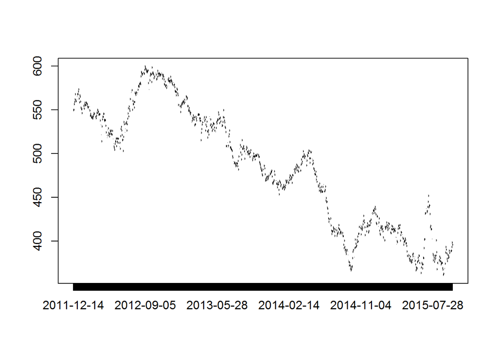

```r
 library(RCurl)
CZ2015 <- getURL("https://www.quandl.com/api/v1/datasets/CME/CZ2015.csv")

plot(CZ2015$Date, CZ2015$Settle)
```

This plot is OK, but it is not exactly up to par when you think about what charts in finance, for example, usually look like. The `quantmod` package has become the most popular R package for charting. Go ahead and install it an load it into your library.

```r
install.packages("quantmod")
install.packages("xts")
library(quantmod)
library(xts)
```

Now, lets plot December 2015 wheat prices that we imported earlier. To do this we will use the function `chartSeries()` from the `quantmod` package. It expects data to be a time series, and it expects to receive Open, High, Low, Close, and Volume.

```r
library(quantmod)
WZ2015_chart <- subset(WZ2015, select= -c(Date, Change, Last, Open.Interest))
WZ2015_chart <- xts(WZ2015_chart, order.by = as.Date(WZ2015$Date))
colnames(WZ2015_chart)[4] <- "Close"

chartSeries(WZ2015_chart['2015-01-01/'], type = "candlesticks", theme = chartTheme("white"))
```

There is a lot going on in this code chunk, actually. Let us go through the details, but what we just did is pretty advanced so do not feel overwhelmed. This was mostly to show you what is possible with financial data. To give you some perspective, it took me about an hour to search around and get the details right.

The three first lines are all prepping the data to put it into the format the `chartSeries()` function expects.

1. In the first line we removed the columns Date, Change, Last, Open.Interest because we need only Open, High, Low, Close.
2. The second line does two things. It defines `WZ2015_chart` as an xts time series object, which is just a special class of object in R. It has attributes some functions written especially for time series data can utilize. The second argument of the `xts()` function uses `order.by` to indicate the `WZ2015$Date` variable should be used as the date index. and the `as.Date()` function puts the data in a proper format the `xts()` function recognizes.
3. The third line changes the column named “Settle”, which is the 4th column to “Close”. This is because `chartSeries()` wants to see columns Open, High, Low, Close, and Volume.

[figure not shown]

[^1]: Documentation for the USDA NASS API can be found http://quickstats.nass.usda.gov/api. At this point, do not worry about understanding how to make sense of the documentation. This is simply a reference for your possible future use. I will provide all the correct URLs in the text.